# Diseño de una sola vía completamente aleatorizado

Kenneth Cabrera

Jueves, 16 de marzo de 2017

## Lectura de la base de datos.

```r
sueño <- read.csv2("Ejemplo1.csv")
sueño$Horas_suprim <- factor(sueño$Horas_suprim)
```

## Análisis exploratorio.

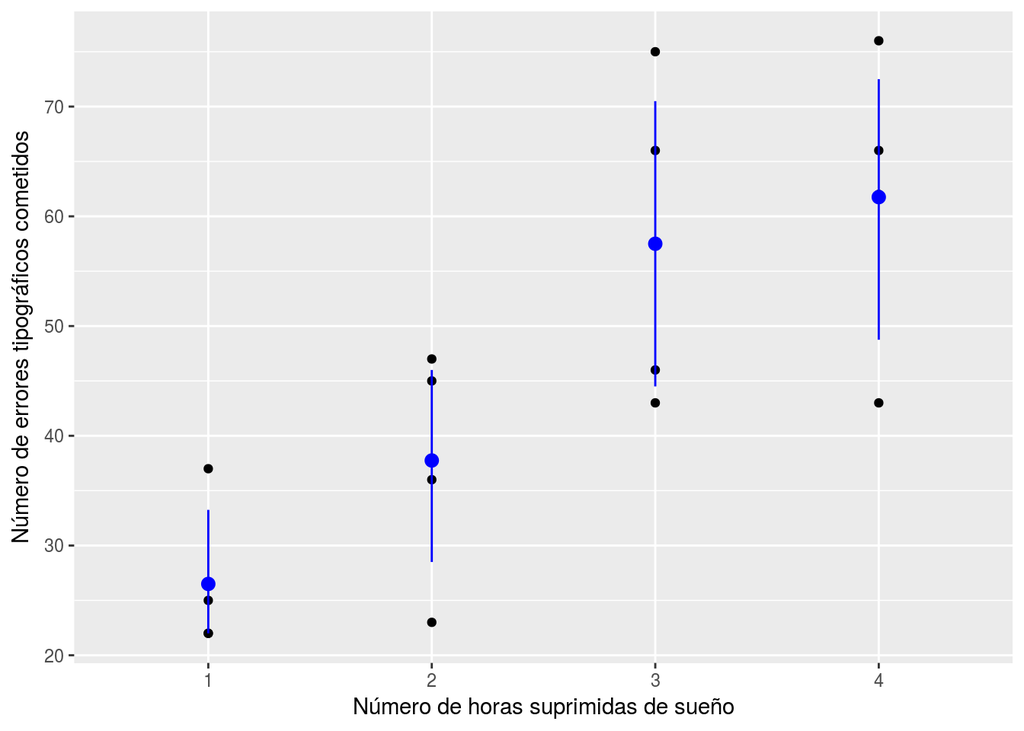

```r
library(ggplot2)
g1 <- ggplot(sueño, aes(Horas_suprim, Errores))
g1 + geom_point() +
     stat_summary(fun.data = "mean_cl_boot",
                  colour = "blue", size = 0.5) +
     ylab("Número de errores tipográficos cometidos") +
     xlab("Número de horas suprimidas de sueño")
```

En el análisis exploratorio se realizó una estimación mediante bootstrap del intervalo de confianza para el promedio de los errores tipográficos obtenidos y se observa que es muy probable que exista diferencia estadísticamente significativa entre los promedios debido a las horas suprimidas de sueño.

## Modelo del experimento.

El modelo ajustado para este caso es:

$$y_{ij} = \mu + \alpha_i + \epsilon_{ij}, \qquad i = 1 \cdots 4, \quad j = 1 \cdots 4 \\
\epsilon_{ij} \sim \mathcal{N}(0,\sigma^2) \quad i.i.d.$$

## Hipótesis principal.

$$H_0: \alpha_1 = \alpha_2 = \alpha_3 = \alpha_4 = 0 \\
H_A: \textrm{Alguna } \alpha_i \textrm{ diferente de } 0$$

## Modelo ajustado de una sola vía.

```r
modelo1 <- aov(Errores ~ Horas_suprim, data = sueño)
summary(modelo1)
```

```
##              Df Sum Sq Mean Sq F value  Pr(>F)
## Horas_suprim  3   3314  1104.7   7.343 0.00471 **
## Residuals    12   1806   150.5
## ---
## Signif. codes:  0 '***' 0.001 '**' 0.01 '*' 0.05 '.' 0.1 ' ' 1
```

Conclusión: Se rechaza $H_0$.

Existe evidencia estadística para concluir que los promedios de los errores cometidos por las personas depende del número de horas de sueño suprimidas.

## Estimación de los parámetros del modelo.

### Estimación de los efectos

```r
model.tables(modelo1, se = TRUE)
```

```
## Tables of effects
##
##  Horas_suprim
## Horas_suprim
##       1       2       3       4
## -19.375  -8.125  11.625  15.875
##
## Standard errors of effects
##         Horas_suprim
##                6.133
## replic.            4
```

Se observa que suprimir una hora de sueño es la que tiene el efecto más alto con respecto al promedio general de errores tipográficos cometidos.

Se observa que sobrepasa el doble la error estándar para los efectos, tanto una hora de sueño suprimida como para cuatro. En otras palabras los casos extremos muestran efectos significativos en comparación con el promedio general.

### Estimación de los promedio por nivel del factor.

```r
model.tables(modelo1, type = "mean", se = TRUE)
```

```
## Tables of means
## Grand mean
##
## 45.875
##
##  Horas_suprim
## Horas_suprim
##     1     2     3     4
## 26.50 37.75 57.50 61.75
##
## Standard errors for differences of means
##         Horas_suprim
##                8.673
## replic.            4
```

El error estándar para la diferencia de medias es de 8.67, una aproximación rápida es observar que la diferencia entre el promedio al suprimir una hora de sueño y cuatro horas de sueño es de aproximadamente 35 errores en promedio y supera claramente el doble de 8.67, es decir 17.34 y por lo tanto muy evidente la diferencia entre suprimir una hora de sueño en contraste con cuatro horas suprimidas de sueño.

Sin embargo dado los supuestos del modelo, es más preciso realizar el análisis de comparación de medias mediante un procedimiento como el de Tukey.

```r
# Estimador de la varianza del error aleatorio
(varErr <- summary(modelo1)[[1]]$"Mean Sq"[2])
```

```
## [1] 150.4583
```

```r
# Estimación de la desviación estándar del error aleatorio
(desvErr <- sqrt(varErr))
```

```
## [1] 12.26615
```

La estimación de la varianza de los errores es de: 150.5. Por lo tanto la estimación de la desviación estándar de los errores es de: 12.3.

Es interesante ver que en general hay una desviación estándar de los errores cometidos en una trasncripción de un documento de aproximadamente 12 errores tipográficos. Esto puede sugerir una heterogeneidad de los participantes del experimento en cuanto a experiencia en la transcripción de documentos, independientemente de las horas suprimidas de sueño.

## Diagnóstico del modelo.

```r
residuales <- residuals(modelo1)
residualesEstandarizados <- rstandard(modelo1) # Residuales estudentizados internos
residualesEstudentizado <- rstudent(modelo1)   # Residuales estudentizados externos
```

### Supuesto de normalidad.

Este supuesto se realiza generalment sobre los residuales, pero es un poco más estricto si se hace sobre los residuales estandarizados.

Si se realiza sobre los residuales estudentizados es para detectar posibles valores influenciales en la estimación del modelo.

```r
shapiro.test(residuales)
```

```
##
##  Shapiro-Wilk normality test
##
## data:  residuales
## W = 0.96068, p-value = 0.6742
```

```r
shapiro.test(residualesEstandarizados)
```

```
##
##  Shapiro-Wilk normality test
##
## data:  residualesEstandarizados
## W = 0.96068, p-value = 0.6742
```

```r
shapiro.test(residualesEstudentizado)
```

```
##
##  Shapiro-Wilk normality test
##
## data:  residualesEstudentizado
## W = 0.97072, p-value = 0.8502
```

### Supesto de igualdad de varianzas.

```r
## Para el caso que los errores se distribuyen normales
bartlett.test(Errores ~ Horas_suprim, data = sueño)
```

```
##
##  Bartlett test of homogeneity of variances
##
## data:  Errores by Horas_suprim
## Bartlett's K-squared = 1.5938, df = 3, p-value = 0.6608
```

```r
## Prueba para el caso que los errores no se distribuyan normal
fligner.test(Errores ~ Horas_suprim, data = sueño)
```

```
##
##  Fligner-Killeen test of homogeneity of variances
##
## data:  Errores by Horas_suprim
## Fligner-Killeen:med chi-squared = 3.0671, df = 3, p-value = 0.3814
```

### Prueba de independiencia.

En este experimento no se puede realizar una prueba de independencia, porque no existe una variable que indique el orde de ejecución de los experimentos o el orden de aleatorización de los mismos.

### Supuestos de linealidad y supuesto de aditividad.

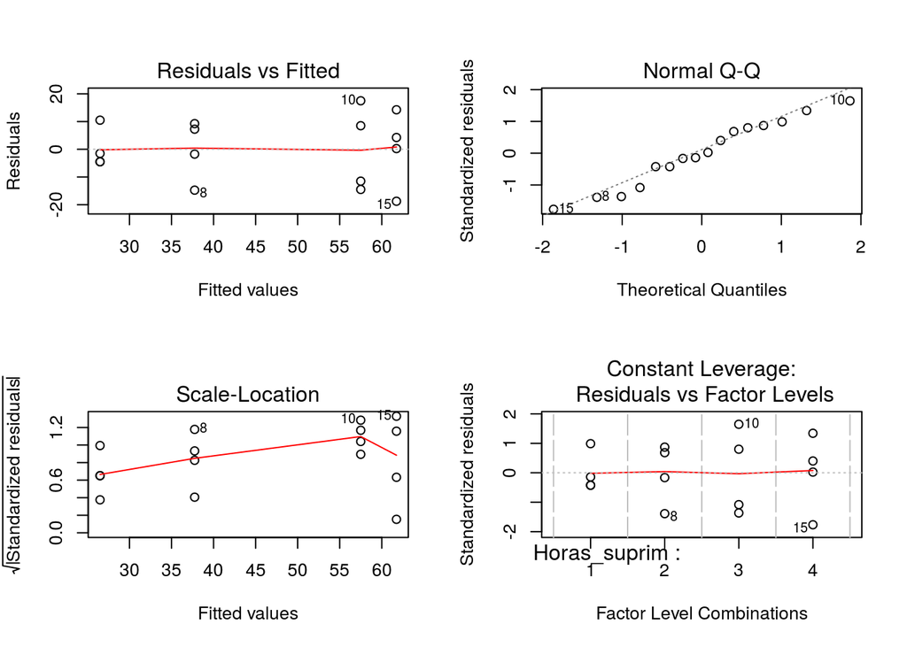

```r
par.orig <- par(no.readonly = TRUE)
par(mfrow = c(2, 2))
plot(modelo1)
```

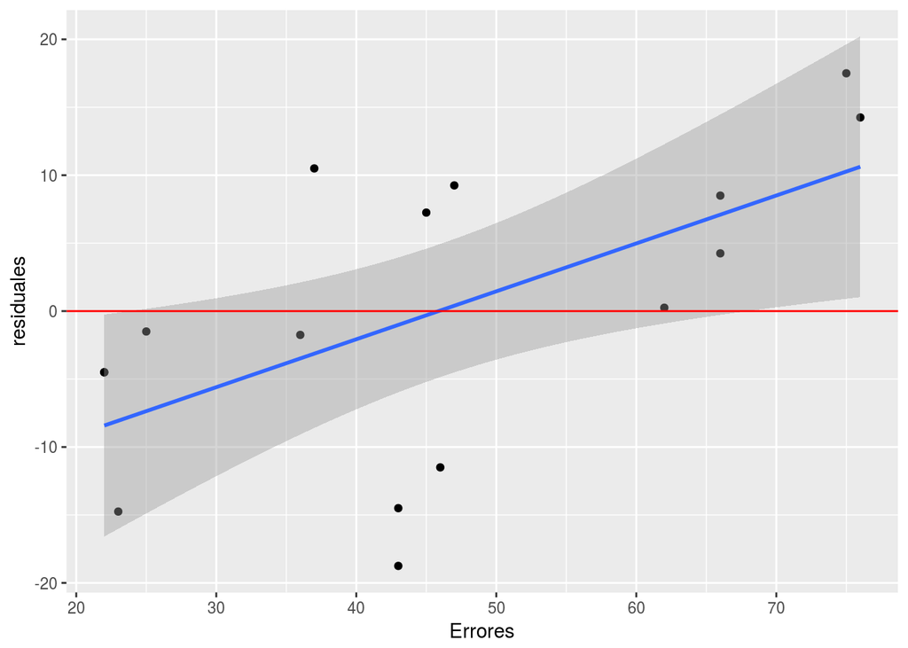

```r
par(par.orig)

sueño$residuales <- residuales
sueño$stdresiduales <- residualesEstandarizados
sueño$studresiduales <- residualesEstudentizado
sueño$predichos <- predict(modelo1)

library(ggplot2)
g1 <- ggplot(sueño, aes(Errores, residuales))
g1 + geom_point() + geom_smooth(method = lm) +
     geom_hline(yintercept = 0, col = "red")
```

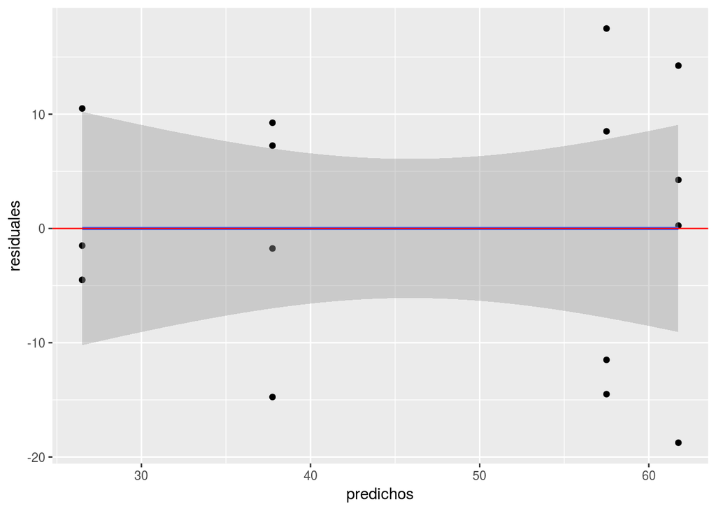

```r
g1 <- ggplot(sueño, aes(predichos, residuales))
g1 + geom_point() + geom_smooth(method = lm) +
     geom_hline(yintercept = 0, col = "red")
```

Bajo el modelo se indica que los efectos de los errores es aditivo con respecto al error promedio general y es aceptable el supuesto de linealidad del modelo inicial.

Sin embargo es posible que existan covariables que estén interviniendo en la respuesta observada pero no se tienen registros de la causa posible de este efecto de covariables.

## Modelo final.

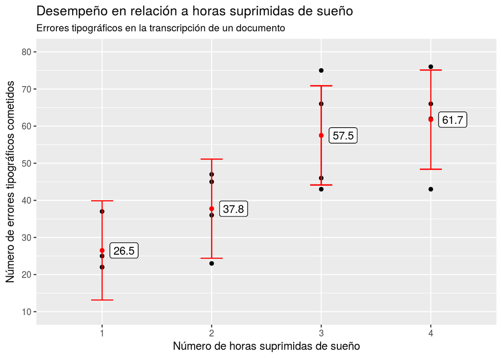

```r
predichosIC <- data.frame(predict(modelo1, interval = "confidence"))
sueño$inf <- predichosIC$lwr
sueño$sup <- predichosIC$upr

library(ggplot2)
g1 <- ggplot(sueño, aes(Horas_suprim, Errores))
g1 + geom_point() +
     geom_point(aes(Horas_suprim, predichos), col = "red") +
     geom_errorbar(aes(ymax = sup, ymin = inf), col = "red", width = 0.2) +
     ylab("Número de errores tipográficos cometidos") +
     xlab("Número de horas suprimidas de sueño") +
     labs(title = "Desempeño en relación a horas suprimidas de sueño",
          subtitle = "Errores tipográficos en la transcripción de un documento") +
     geom_label(aes(Horas_suprim, predichos, label = round(predichos,1)),
               nudge_x = 0.2) +
     scale_y_continuous(breaks = seq(10, 80, 10), limits = c(10, 80))
```

## Comparación de medias.

```r
(THSD <- TukeyHSD(modelo1))
```

```
##   Tukey multiple comparisons of means
##     95% family-wise confidence level
##
## Fit: aov(formula = Errores ~ Horas_suprim, data = sueño)
##
## $Horas_suprim
##      diff        lwr      upr     p adj
## 2-1 11.25 -14.500689 37.00069 0.5817551
## 3-1 31.00   5.249311 56.75069 0.0173828
## 4-1 35.25   9.499311 61.00069 0.0073920
## 3-2 19.75  -6.000689 45.50069 0.1581707
## 4-2 24.00  -1.750689 49.75069 0.0706593
## 4-3  4.25 -21.500689 30.00069 0.9598438
```

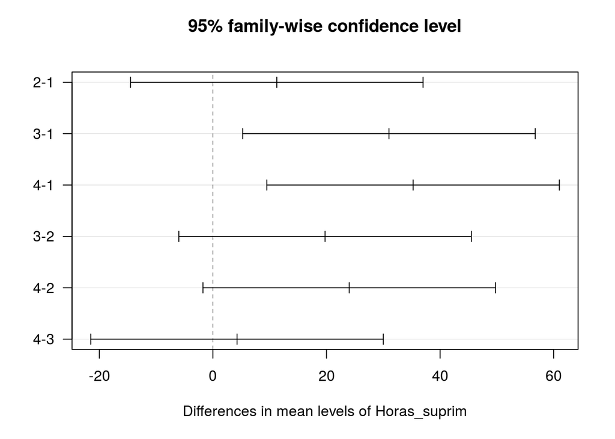

```r
plot(THSD, las = 1)
```

## Conclusiones.

- Existe una clara evidencia que la supresión de horas de sueño inflyen en el promedio de errores tipográficos cometidos en general en las personas al desarrollar una tarea de transcripción de un documento.
- El promedio de los errores tipográficos cometidos aumenta con el número de horas suprimidas, sin embargo no se observa que la tasa incremento en el promedio de número de errores siga un ritmo constante, de decir que la relación entre las horas suprimidas y el número de errores no es lineal.
- Con respecto a una hora de sueño suprimida hay evidencia estadística que existe diferencia en el promedio de errores con respecto suprimir tres o cuatro horas de sueño, pero no con respecto a suprimir dos horas de sueño.
- Sin embargo no es evidente la diferencia entre suprimir dos horas de sueño en comparación con tres y cuatro horas de sueño.
- No hay evidencia que suprimir tres horas de sueño sea diferente en relación al promedio de errores cometidos cuando se suprimen cuatro horas de sueño.
- No se logró encontrar diferencias en cada comparación debido a la alta variabilidad de los errores cometidos por los participantes del experimento.

## Recomendaciones.

- Este comportamiento hace pensar que existe algún punto crítico cuando se sobrepasan las dos horas suprimidas de sueño y luego se tiende a estabilizar cuando el número de horas de supresión sean de tres o más. En este caso sería necesario un estudio más completo.
- También los resultados hacen sospechar que exista algua o algunas covariables con respecto a características propias de las personas que influencien el efecto en la supresión de horas de sueño en el desempeño de la trasncripción de un documento. Se recomiendo por lo tanto en un experimento futuro registrar algunas covariables o realizar algún bloqueo por características de las personas.
- En futuros experimentos se recomienda registrar el orden de aleatorización para verificar el supuesto de independencia del modelo.
- Se recomienda seleccionar una población objetivo con menor variación para evidenciar de manera más clara la diferencia en la supresión de las horas de sueño.